# Chapter 4

Source: https://github.com/xw1120/My-Solutions-to-ISLR/blob/master/ch4/ch4.Rmd.

## Applied Questions

### Excercise 10a

```r
library(ISLR)
attach(Weekly)
summary(Weekly)
```

```
##       Year           Lag1               Lag2               Lag3
##  Min.   :1990   Min.   :-18.1950   Min.   :-18.1950   Min.   :-18.1950
##  1st Qu.:1995   1st Qu.: -1.1540   1st Qu.: -1.1540   1st Qu.: -1.1580
##  Median :2000   Median :  0.2410   Median :  0.2410   Median :  0.2410
##  Mean   :2000   Mean   :  0.1506   Mean   :  0.1511   Mean   :  0.1472
##  3rd Qu.:2005   3rd Qu.:  1.4050   3rd Qu.:  1.4090   3rd Qu.:  1.4090
##  Max.   :2010   Max.   : 12.0260   Max.   : 12.0260   Max.   : 12.0260
##       Lag4               Lag5              Volume
##  Min.   :-18.1950   Min.   :-18.1950   Min.   :0.08747
##  1st Qu.: -1.1580   1st Qu.: -1.1660   1st Qu.:0.33202
##  Median :  0.2380   Median :  0.2340   Median :1.00268
##  Mean   :  0.1458   Mean   :  0.1399   Mean   :1.57462
##  3rd Qu.:  1.4090   3rd Qu.:  1.4050   3rd Qu.:2.05373
##  Max.   : 12.0260   Max.   : 12.0260   Max.   :9.32821
##      Today          Direction
##  Min.   :-18.1950   Down:484
##  1st Qu.: -1.1540   Up  :605
##  Median :  0.2410
##  Mean   :  0.1499
##  3rd Qu.:  1.4050
##  Max.   : 12.0260
```

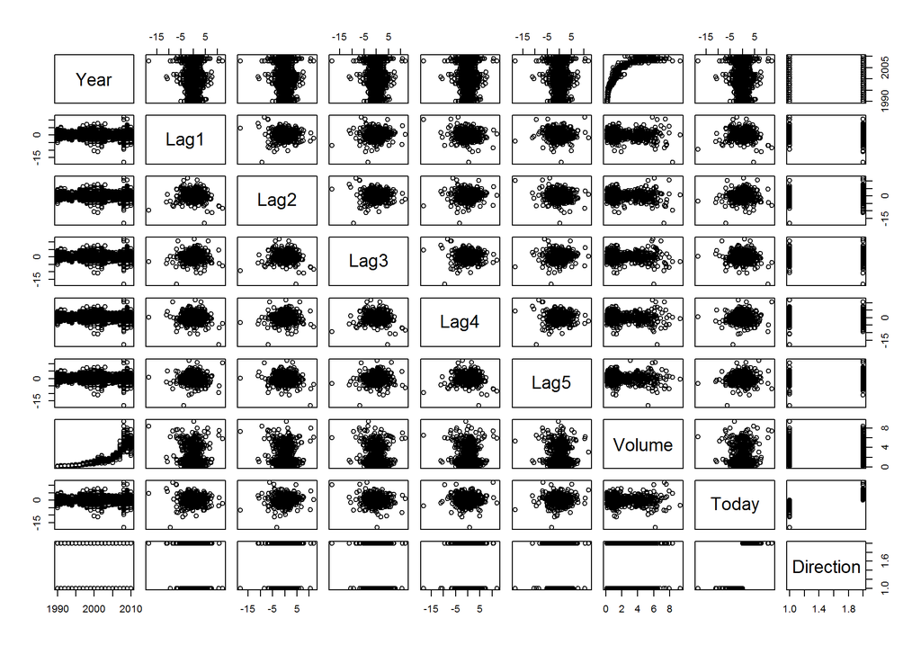

```r
pairs(Weekly)
```

```r
cor(Weekly[, -9])
```

```
##               Year         Lag1        Lag2        Lag3         Lag4
## Year    1.00000000 -0.032289274 -0.03339001 -0.03000649 -0.031127923
## Lag1   -0.03228927  1.000000000 -0.07485305  0.05863568 -0.071273876
## Lag2   -0.03339001 -0.074853051  1.00000000 -0.07572091  0.058381535
## Lag3   -0.03000649  0.058635682 -0.07572091  1.00000000 -0.075395865
## Lag4   -0.03112792 -0.071273876  0.05838153 -0.07539587  1.000000000
## Lag5   -0.03051910 -0.008183096 -0.07249948  0.06065717 -0.075675027
## Volume  0.84194162 -0.064951313 -0.08551314 -0.06928771 -0.061074617
## Today  -0.03245989 -0.075031842  0.05916672 -0.07124364 -0.007825873
##                Lag5      Volume        Today
## Year   -0.030519101  0.84194162 -0.032459894
## Lag1   -0.008183096 -0.06495131 -0.075031842
## Lag2   -0.072499482 -0.08551314  0.059166717
## Lag3    0.060657175 -0.06928771 -0.071243639
## Lag4   -0.075675027 -0.06107462 -0.007825873
## Lag5    1.000000000 -0.05851741  0.011012698
## Volume -0.058517414  1.00000000 -0.033077783
## Today   0.011012698 -0.03307778  1.000000000
```

The most apparent pattern is that as the Year increases, the Volume increases with a quadratic form.

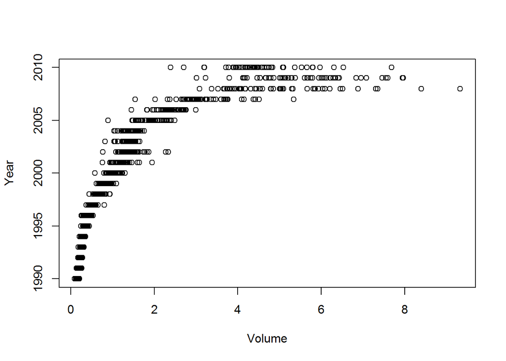

```r
plot(Volume, Year)
```

### Excercise 10b

```r
glm.fit = glm(Direction~.-Year-Today, data = Weekly, family = binomial)
summary(glm.fit)
```

```
##
## Call:
## glm(formula = Direction ~ . - Year - Today, family = binomial,
##     data = Weekly)
##
## Deviance Residuals:
##     Min       1Q   Median       3Q      Max
## -1.6949  -1.2565   0.9913   1.0849   1.4579
##
## Coefficients:
##             Estimate Std. Error z value Pr(>|z|)
## (Intercept)  0.26686    0.08593   3.106   0.0019 **
## Lag1        -0.04127    0.02641  -1.563   0.1181
## Lag2         0.05844    0.02686   2.175   0.0296 *
## Lag3        -0.01606    0.02666  -0.602   0.5469
## Lag4        -0.02779    0.02646  -1.050   0.2937
## Lag5        -0.01447    0.02638  -0.549   0.5833
## Volume      -0.02274    0.03690  -0.616   0.5377
## ---
## Signif. codes:  0 '***' 0.001 '**' 0.01 '*' 0.05 '.' 0.1 ' ' 1
##
## (Dispersion parameter for binomial family taken to be 1)
##
##     Null deviance: 1496.2  on 1088  degrees of freedom
## Residual deviance: 1486.4  on 1082  degrees of freedom
## AIC: 1500.4
##
## Number of Fisher Scoring iterations: 4
```

Only predictor *Lag2* is statistically significant.

### Excercise 10c

```r
glm.probs = predict(glm.fit, type = "response")
contrasts(Direction)
```

```
##      Up
## Down  0
## Up    1
```

```r
glm.pred = rep("Down", length(glm.probs))
glm.pred[glm.probs > .5] = "Up"
table(glm.pred, Direction)
```

```
##         Direction
## glm.pred Down  Up
##     Down   54  48
##     Up    430 557
```

```r
mean(glm.pred == Direction)
```

```
## [1] 0.5610652
```

The confusion matrix shows that the logistic classifier incorrectly classifies $48/(48+557) = \%7.9$ Ups as Downs, and incorrectly classifies $430/(54+430) = \%88.8$ Downs as Ups.

### Excercise 10d

```r
train = Year < 2009
Weekly.test = Weekly[!train, ]
Direction.test = Direction[!train]
```

```r
glm.fit = glm(Direction~Lag2, family=binomial, subset=train)
glm.probs = predict(glm.fit, Weekly.test, type = "response")
glm.pred = rep("Down", length(glm.probs))
glm.pred[glm.probs > .5] = "Up"
table(glm.pred, Direction.test)
```

```
##         Direction.test
## glm.pred Down Up
##     Down    9  5
##     Up     34 56
```

```r
mean(glm.pred == Direction.test)
```

```
## [1] 0.625
```

### Excercise 10e

```r
library(MASS) # for lda() function
lda.fit = lda(Direction~Lag2, subset=train)
lda.pred = predict(lda.fit, Weekly.test)
lda.class = lda.pred$class
table(lda.class, Direction.test)
```

```
##          Direction.test
## lda.class Down Up
##      Down    9  5
##      Up     34 56
```

```r
mean(lda.class == Direction.test)
```

```
## [1] 0.625
```

### Excercise 10f

```r
qda.fit = qda(Direction~Lag2, subset=train)
qda.pred = predict(qda.fit, Weekly.test)
qda.class = qda.pred$class
table(qda.class, Direction.test)
```

```
##          Direction.test
## qda.class Down Up
##      Down    0  0
##      Up     43 61
```

```r
mean(qda.class == Direction.test)
```

```
## [1] 0.5865385
```

### Excercise 10g

```r
library(class) # for KNN function
train.X = as.matrix(Lag2[train])
test.X = as.matrix(Lag2[!train])
train.Direction = Direction[train]
set.seed(1)
knn.pred = knn(train.X, test.X, train.Direction, k = 1)
table(knn.pred, Direction.test)
```

```
##         Direction.test
## knn.pred Down Up
##     Down   21 30
##     Up     22 31
```

```r
mean(knn.pred == Direction.test)
```

```
## [1] 0.5
```

### Excercise 10h

Both logistic classifier and LDA have the highest overall accuracy rate %62.5.

### Excercise 10i

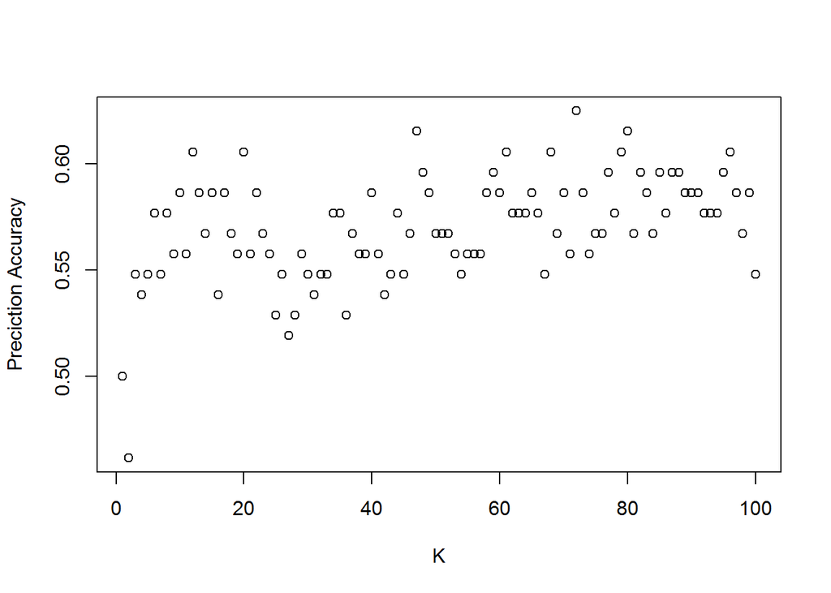

```r
knn_accuracy = c();
for ( i in 1:100 ) {
  knn.pred = knn(train.X, test.X, train.Direction, k = i)
  knn_accuracy[i] = mean(knn.pred == Direction.test)
}
plot(1:100, knn_accuracy, xlab = "K", ylab = "Preciction Accuracy")
```

```r
which.max(knn_accuracy)
```

```
## [1] 72
```

For KNN, the best result can be obtained when K = 72.

```r
# clean up
rm(list = ls())
```

### Excercise 13

```r
library(MASS)
summary(Boston)
```

```
##       crim                zn             indus            chas
##  Min.   : 0.00632   Min.   :  0.00   Min.   : 0.46   Min.   :0.00000
##  1st Qu.: 0.08204   1st Qu.:  0.00   1st Qu.: 5.19   1st Qu.:0.00000
##  Median : 0.25651   Median :  0.00   Median : 9.69   Median :0.00000
##  Mean   : 3.61352   Mean   : 11.36   Mean   :11.14   Mean   :0.06917
##  3rd Qu.: 3.67708   3rd Qu.: 12.50   3rd Qu.:18.10   3rd Qu.:0.00000
##  Max.   :88.97620   Max.   :100.00   Max.   :27.74   Max.   :1.00000
##       nox               rm             age              dis
##  Min.   :0.3850   Min.   :3.561   Min.   :  2.90   Min.   : 1.130
##  1st Qu.:0.4490   1st Qu.:5.886   1st Qu.: 45.02   1st Qu.: 2.100
##  Median :0.5380   Median :6.208   Median : 77.50   Median : 3.207
##  Mean   :0.5547   Mean   :6.285   Mean   : 68.57   Mean   : 3.795
##  3rd Qu.:0.6240   3rd Qu.:6.623   3rd Qu.: 94.08   3rd Qu.: 5.188
##  Max.   :0.8710   Max.   :8.780   Max.   :100.00   Max.   :12.127
##       rad              tax           ptratio          black
##  Min.   : 1.000   Min.   :187.0   Min.   :12.60   Min.   :  0.32
##  1st Qu.: 4.000   1st Qu.:279.0   1st Qu.:17.40   1st Qu.:375.38
##  Median : 5.000   Median :330.0   Median :19.05   Median :391.44
##  Mean   : 9.549   Mean   :408.2   Mean   :18.46   Mean   :356.67
##  3rd Qu.:24.000   3rd Qu.:666.0   3rd Qu.:20.20   3rd Qu.:396.23
##  Max.   :24.000   Max.   :711.0   Max.   :22.00   Max.   :396.90
##      lstat            medv
##  Min.   : 1.73   Min.   : 5.00
##  1st Qu.: 6.95   1st Qu.:17.02
##  Median :11.36   Median :21.20
##  Mean   :12.65   Mean   :22.53
##  3rd Qu.:16.95   3rd Qu.:25.00
##  Max.   :37.97   Max.   :50.00
```

```r
crim01 = rep(0, length(Boston$crim))
crim01[Boston$crim > median(Boston$crim)] = 1
newBoston = data.frame(crim01 = crim01, subset(Boston, select=-crim))
rm(crim01) # crucial!
attach(newBoston)
summary(newBoston)
```

```
##      crim01          zn             indus            chas
##  Min.   :0.0   Min.   :  0.00   Min.   : 0.46   Min.   :0.00000
##  1st Qu.:0.0   1st Qu.:  0.00   1st Qu.: 5.19   1st Qu.:0.00000
##  Median :0.5   Median :  0.00   Median : 9.69   Median :0.00000
##  Mean   :0.5   Mean   : 11.36   Mean   :11.14   Mean   :0.06917
##  3rd Qu.:1.0   3rd Qu.: 12.50   3rd Qu.:18.10   3rd Qu.:0.00000
##  Max.   :1.0   Max.   :100.00   Max.   :27.74   Max.   :1.00000
##       nox               rm             age              dis
##  Min.   :0.3850   Min.   :3.561   Min.   :  2.90   Min.   : 1.130
##  1st Qu.:0.4490   1st Qu.:5.886   1st Qu.: 45.02   1st Qu.: 2.100
##  Median :0.5380   Median :6.208   Median : 77.50   Median : 3.207
##  Mean   :0.5547   Mean   :6.285   Mean   : 68.57   Mean   : 3.795
##  3rd Qu.:0.6240   3rd Qu.:6.623   3rd Qu.: 94.08   3rd Qu.: 5.188
##  Max.   :0.8710   Max.   :8.780   Max.   :100.00   Max.   :12.127
##       rad              tax           ptratio          black
##  Min.   : 1.000   Min.   :187.0   Min.   :12.60   Min.   :  0.32
##  1st Qu.: 4.000   1st Qu.:279.0   1st Qu.:17.40   1st Qu.:375.38
##  Median : 5.000   Median :330.0   Median :19.05   Median :391.44
##  Mean   : 9.549   Mean   :408.2   Mean   :18.46   Mean   :356.67
##  3rd Qu.:24.000   3rd Qu.:666.0   3rd Qu.:20.20   3rd Qu.:396.23
##  Max.   :24.000   Max.   :711.0   Max.   :22.00   Max.   :396.90
##      lstat            medv
##  Min.   : 1.73   Min.   : 5.00
##  1st Qu.: 6.95   1st Qu.:17.02
##  Median :11.36   Median :21.20
##  Mean   :12.65   Mean   :22.53
##  3rd Qu.:16.95   3rd Qu.:25.00
##  Max.   :37.97   Max.   :50.00
```

```r
cor(newBoston)
```

```
##              crim01          zn       indus         chas         nox
## crim01   1.00000000 -0.43615103  0.60326017  0.070096774  0.72323480
## zn      -0.43615103  1.00000000 -0.53382819 -0.042696719 -0.51660371
## indus    0.60326017 -0.53382819  1.00000000  0.062938027  0.76365145
## chas     0.07009677 -0.04269672  0.06293803  1.000000000  0.09120281
## nox      0.72323480 -0.51660371  0.76365145  0.091202807  1.00000000
## rm      -0.15637178  0.31199059 -0.39167585  0.091251225 -0.30218819
## age      0.61393992 -0.56953734  0.64477851  0.086517774  0.73147010
##                  rm         age         dis          rad         tax
## crim01  -0.15637178  0.61393992 -0.61634164  0.619786249  0.60874128
## zn       0.31199059 -0.56953734  0.66440822 -0.311947826 -0.31456332
## indus   -0.39167585  0.64477851 -0.70802699  0.595129275  0.72076018
## chas     0.09125123  0.08651777 -0.09917578 -0.007368241 -0.03558652
## nox     -0.30218819  0.73147010 -0.76923011  0.611440563  0.66802320
## rm       1.00000000 -0.24026493  0.20524621 -0.209846668 -0.29204783
## age     -0.24026493  1.00000000 -0.74788054  0.456022452  0.50645559
##            ptratio       black      lstat       medv
## crim01   0.2535684 -0.35121093  0.4532627 -0.2630167
## zn      -0.3916785  0.17552032 -0.4129946  0.3604453
## indus    0.3832476 -0.35697654  0.6037997 -0.4837252
## chas    -0.1215152  0.04878848 -0.0539293  0.1752602
## nox      0.1889327 -0.38005064  0.5908789 -0.4273208
## rm      -0.3555015  0.12806864 -0.6138083  0.6953599
## age      0.2615150 -0.27353398  0.6023385 -0.3769546
##  [ reached getOption("max.print") -- omitted 7 rows ]
```

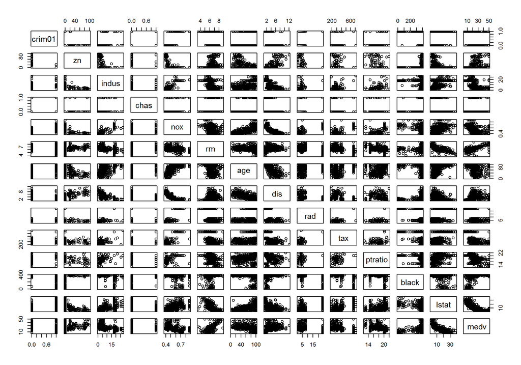

```r
pairs(newBoston)
```

We pick out the six discriminant features according to correlation measurement, they are: indus, nox, age, dis, rad, tax.

Besides, we’ve also discovered the following correlations among predictors: * indus has strong correlation with nox, age, dis, tax * nox has strong correlation with age, dis, and moderate correlation with rad, tax, lastat. * age has a strong correlation with dis, and a moderate correlation with lstat. * dis has moderate correalation with zn * rad has strong correlation with tax

Splitting dataset into training set and test set:

```r
ratio = 0.75 # ratio of training set to whole set
sample_size = floor(ratio * nrow(newBoston))
set.seed(1) # make results reproducible
train_ind = sample(seq_len(nrow(newBoston)),  replace = FALSE, size = sample_size)
train = rep(FALSE, nrow(newBoston))
train[train_ind] = TRUE
train.X = cbind(indus, nox, age, dis, rad, tax)[train, ]
test.X = newBoston[!train, ]
train.Y = crim01[train]
test.Y = crim01[!train]
```

Fitting using Logistic regression:

```r
glm.fit = glm(crim01~indus+nox+age+dis+rad+tax, data = newBoston, family = binomial, subset = train)
summary(glm.fit)
```

```
##
## Call:
## glm(formula = crim01 ~ indus + nox + age + dis + rad + tax, family = binomial,
##     data = newBoston, subset = train)
##
## Deviance Residuals:
##      Min        1Q    Median        3Q       Max
## -1.98253  -0.25242   0.00027   0.01325   2.93321
##
## Coefficients:
##               Estimate Std. Error z value    Pr(>|z|)
## (Intercept) -27.072695   4.724375  -5.730 0.000000010 ***
## indus        -0.092380   0.051464  -1.795     0.07265 .
## nox          44.441175   8.508333   5.223 0.000000176 ***
## age           0.034362   0.011576   2.969     0.00299 **
## dis           0.328693   0.177661   1.850     0.06430 .
## rad           0.529787   0.135544   3.909 0.000092837 ***
## tax          -0.007556   0.002929  -2.579     0.00990 **
## ---
## Signif. codes:  0 '***' 0.001 '**' 0.01 '*' 0.05 '.' 0.1 ' ' 1
##
## (Dispersion parameter for binomial family taken to be 1)
##
##     Null deviance: 525.38  on 378  degrees of freedom
## Residual deviance: 174.55  on 372  degrees of freedom
## AIC: 188.55
##
## Number of Fisher Scoring iterations: 9
```

```r
glm.probs = predict(glm.fit, test.X, type = "response")
glm.pred = rep(0, length(glm.probs))
glm.pred[glm.probs > .5] = 1
table(glm.pred, test.Y)
```

```
##         test.Y
## glm.pred  0  1
##        0 59  8
##        1  6 54
```

```r
mean(glm.pred == test.Y)
```

```
## [1] 0.8897638
```

Adding interaction terms, we have

```r
glm.fit2 = glm(crim01~indus+nox+age+dis+rad+tax+
                 indus:nox+indus:age+indus:dis+indus:tax+nox:age+nox:dis+nox:rad+nox:tax+age:lstat+age:dis+age:lstat+dis:zn+rad:tax,
               family = binomial, subset = train)
summary(glm.fit2)
```

```
##
## Call:
## glm(formula = crim01 ~ indus + nox + age + dis + rad + tax +
##     indus:nox + indus:age + indus:dis + indus:tax + nox:age +
##     nox:dis + nox:rad + nox:tax + age:lstat + age:dis + age:lstat +
##     dis:zn + rad:tax, family = binomial, subset = train)
##
## Deviance Residuals:
##     Min       1Q   Median       3Q      Max
## -2.1511  -0.2414   0.0000   0.0369   3.6276
##
## Coefficients:
##                Estimate  Std. Error z value Pr(>|z|)
## (Intercept) -28.0145171  26.5157253  -1.057   0.2907
## indus        -2.5965299   1.6720248  -1.553   0.1204
## nox          57.1041355  54.0511477   1.056   0.2907
## age          -0.3844504   0.1968482  -1.953   0.0508 .
## dis           0.8866715   2.6732709   0.332   0.7401
## rad           1.5924404   1.6453796   0.968   0.3331
## tax           0.1009229   0.0747683   1.350   0.1771
## indus:nox     3.1948958   2.4579816   1.300   0.1937
## indus:age     0.0001203   0.0040850   0.029   0.9765
## indus:dis     0.1841043   0.1154584   1.595   0.1108
## indus:tax     0.0006690   0.0007026   0.952   0.3410
## nox:age       0.7494439   0.3462431   2.165   0.0304 *
## nox:dis      -4.0181148   5.5981822  -0.718   0.4729
## nox:rad      -1.3776808   3.7637406  -0.366   0.7143
## nox:tax      -0.2194357   0.1501651  -1.461   0.1439
## age:lstat    -0.0000600   0.0005901  -0.102   0.9190
## age:dis       0.0084738   0.0106493   0.796   0.4262
## dis:zn       -0.0255636   0.0105006  -2.434   0.0149 *
## rad:tax      -0.0001816   0.0014776  -0.123   0.9022
## ---
## Signif. codes:  0 '***' 0.001 '**' 0.01 '*' 0.05 '.' 0.1 ' ' 1
##
## (Dispersion parameter for binomial family taken to be 1)
##
##     Null deviance: 525.38  on 378  degrees of freedom
## Residual deviance: 149.77  on 360  degrees of freedom
## AIC: 187.77
##
## Number of Fisher Scoring iterations: 10
```

```r
glm.probs = predict(glm.fit2, test.X, type = "response")
glm.pred = rep(0, length(glm.probs))
glm.pred[glm.probs > .5] = 1
table(glm.pred, test.Y)
```

```
##         test.Y
## glm.pred  0  1
##        0 60  8
##        1  5 54
```

```r
mean(glm.pred == test.Y)
```

```
## [1] 0.8976378
```

As we can see from above p-values, we only need to keep interactions of nox:age and dis:zn, then we have:

```r
glm.fit3 = glm(crim01~indus+nox+age+dis+rad+tax+nox:age+dis:zn,
               family = binomial, subset = train)
summary(glm.fit3)
```

```
##
## Call:
## glm(formula = crim01 ~ indus + nox + age + dis + rad + tax +
##     nox:age + dis:zn, family = binomial, subset = train)
##
## Deviance Residuals:
##     Min       1Q   Median       3Q      Max
## -1.9933  -0.2580   0.0000   0.0029   3.1768
##
## Coefficients:
##              Estimate Std. Error z value  Pr(>|z|)
## (Intercept) -3.096390   9.618424  -0.322   0.74751
## indus       -0.125937   0.065197  -1.932   0.05340 .
## nox         -5.035583  18.331281  -0.275   0.78355
## age         -0.295932   0.135704  -2.181   0.02920 *
## dis          0.622896   0.223141   2.791   0.00525 **
## rad          0.701973   0.165460   4.243 0.0000221 ***
## tax         -0.009043   0.003355  -2.695   0.00704 **
## nox:age      0.652771   0.268828   2.428   0.01517 *
## dis:zn      -0.021121   0.006887  -3.067   0.00216 **
## ---
## Signif. codes:  0 '***' 0.001 '**' 0.01 '*' 0.05 '.' 0.1 ' ' 1
##
## (Dispersion parameter for binomial family taken to be 1)
##
##     Null deviance: 525.38  on 378  degrees of freedom
## Residual deviance: 159.20  on 370  degrees of freedom
## AIC: 177.2
##
## Number of Fisher Scoring iterations: 9
```

```r
glm.probs = predict(glm.fit3, test.X, type = "response")
glm.pred = rep(0, length(glm.probs))
glm.pred[glm.probs > .5] = 1
table(glm.pred, test.Y)
```

```
##         test.Y
## glm.pred  0  1
##        0 60  9
##        1  5 53
```

```r
mean(glm.pred == test.Y)
```

```
## [1] 0.8897638
```

Getting rid of *nox*, which is not statistically significant:

```r
glm.fit3 = glm(crim01~indus+age+dis+rad+tax+nox:age+dis:zn,
               family = binomial, subset = train)
summary(glm.fit3)
```

```
##
## Call:
## glm(formula = crim01 ~ indus + age + dis + rad + tax + nox:age +
##     dis:zn, family = binomial, subset = train)
##
## Deviance Residuals:
##     Min       1Q   Median       3Q      Max
## -1.9835  -0.2466   0.0000   0.0032   3.1882
##
## Coefficients:
##              Estimate Std. Error z value    Pr(>|z|)
## (Intercept) -5.700625   1.782652  -3.198     0.00138 **
## indus       -0.119854   0.060846  -1.970     0.04886 *
## age         -0.263009   0.062378  -4.216 0.000024824 ***
## dis          0.632556   0.221215   2.859     0.00424 **
## rad          0.694650   0.163001   4.262 0.000020295 ***
## tax         -0.008893   0.003288  -2.704     0.00685 **
## age:nox      0.587016   0.118349   4.960 0.000000705 ***
## dis:zn      -0.020749   0.006805  -3.049     0.00230 **
## ---
## Signif. codes:  0 '***' 0.001 '**' 0.01 '*' 0.05 '.' 0.1 ' ' 1
##
## (Dispersion parameter for binomial family taken to be 1)
##
##     Null deviance: 525.38  on 378  degrees of freedom
## Residual deviance: 159.27  on 371  degrees of freedom
## AIC: 175.27
##
## Number of Fisher Scoring iterations: 9
```

```r
glm.probs = predict(glm.fit3, test.X, type = "response")
glm.pred = rep(0, length(glm.probs))
glm.pred[glm.probs > .5] = 1
table(glm.pred, test.Y)
```

```
##         test.Y
## glm.pred  0  1
##        0 60  9
##        1  5 53
```

```r
mean(glm.pred == test.Y)
```

```
## [1] 0.8897638
```

We can also try to add some transformations of predictors:

```r
glm.fit4 = glm(crim01~poly(indus,2)+poly(age,2)+poly(dis,2)+poly(rad,2)+poly(tax,2)+nox:age+dis:zn,
               family = binomial, subset = train)
summary(glm.fit4)
```

```
##
## Call:
## glm(formula = crim01 ~ poly(indus, 2) + poly(age, 2) + poly(dis,
##     2) + poly(rad, 2) + poly(tax, 2) + nox:age + dis:zn, family = binomial,
##     subset = train)
##
## Deviance Residuals:
##     Min       1Q   Median       3Q      Max
## -1.7678  -0.1747   0.0001   0.0228   3.7549
##
## Coefficients:
##                    Estimate  Std. Error z value   Pr(>|z|)
## (Intercept)      -25.099988    5.514190  -4.552 0.00000532 ***
## poly(indus, 2)1    6.936604   12.636067   0.549   0.583038
## poly(indus, 2)2   23.634336    9.352948   2.527   0.011506 *
## poly(age, 2)1   -203.797422   47.376116  -4.302 0.00001695 ***
## poly(age, 2)2     -3.060746    6.817459  -0.449   0.653463
## poly(dis, 2)1     12.838824   17.450013   0.736   0.461884
## poly(dis, 2)2    -46.851987   19.955197  -2.348   0.018882 *
## poly(rad, 2)1    478.388531  121.371412   3.942 0.00008096 ***
## poly(rad, 2)2     61.393682   20.573399   2.984   0.002844 **
## poly(tax, 2)1   -400.930641  109.638902  -3.657   0.000255 ***
## poly(tax, 2)2   -155.588316   43.307132  -3.593   0.000327 ***
## nox:age            0.673375    0.138833   4.850 0.00000123 ***
## dis:zn            -0.012637    0.008651  -1.461   0.144061
## ---
## Signif. codes:  0 '***' 0.001 '**' 0.01 '*' 0.05 '.' 0.1 ' ' 1
##
## (Dispersion parameter for binomial family taken to be 1)
##
##     Null deviance: 525.38  on 378  degrees of freedom
## Residual deviance: 122.79  on 366  degrees of freedom
## AIC: 148.79
##
## Number of Fisher Scoring iterations: 11
```

```r
glm.probs = predict(glm.fit4, test.X, type = "response")
glm.pred = rep(0, length(glm.probs))
glm.pred[glm.probs > .5] = 1
table(glm.pred, test.Y)
```

```
##         test.Y
## glm.pred  0  1
##        0 59  8
##        1  6 54
```

```r
mean(glm.pred == test.Y)
```

```
## [1] 0.8897638
```

The squares of indus, dis, rad, tax are statistically significant, therefore, we have the final combinations of predictors:

```r
glm.fit4 = glm(crim01~I(indus^2)+age+I(dis^2)+poly(rad,2)+poly(tax,2)+nox:age+dis:zn,
               family = binomial, subset = train)
summary(glm.fit4)
```

```
##
## Call:
## glm(formula = crim01 ~ I(indus^2) + age + I(dis^2) + poly(rad,
##     2) + poly(tax, 2) + nox:age + dis:zn, family = binomial,
##     subset = train)
##
## Deviance Residuals:
##     Min       1Q   Median       3Q      Max
## -2.0821  -0.1341   0.0002   0.0201   3.8680
##
## Coefficients:
##                  Estimate  Std. Error z value   Pr(>|z|)
## (Intercept)     -3.456564    1.522824  -2.270    0.02322 *
## I(indus^2)       0.002389    0.002874   0.831    0.40587
## age             -0.266905    0.067394  -3.960 0.00007484 ***
## I(dis^2)         0.049562    0.029908   1.657    0.09749 .
## poly(rad, 2)1  424.308663   90.678250   4.679 0.00000288 ***
## poly(rad, 2)2   46.655534   14.619566   3.191    0.00142 **
## poly(tax, 2)1 -362.221548   85.342993  -4.244 0.00002193 ***
## poly(tax, 2)2 -126.244608   32.078227  -3.936 0.00008302 ***
## age:nox          0.566396    0.125724   4.505 0.00000663 ***
## dis:zn          -0.023187    0.008458  -2.742    0.00612 **
## ---
## Signif. codes:  0 '***' 0.001 '**' 0.01 '*' 0.05 '.' 0.1 ' ' 1
##
## (Dispersion parameter for binomial family taken to be 1)
##
##     Null deviance: 525.38  on 378  degrees of freedom
## Residual deviance: 134.71  on 369  degrees of freedom
## AIC: 154.71
##
## Number of Fisher Scoring iterations: 10
```

```r
glm.probs = predict(glm.fit4, test.X, type = "response")
glm.pred = rep(0, length(glm.probs))
glm.pred[glm.probs > .5] = 1
table(glm.pred, test.Y)
```

```
##         test.Y
## glm.pred  0  1
##        0 61  8
##        1  4 54
```

```r
mean(glm.pred == test.Y)
```

```
## [1] 0.9055118
```

As we can see, the prediction accuracy has increased from %88.98 to %90.55.

Furthurmore, if we adjust the threshold for logistic regression, using

```r
logistic_pred_accuracy = c()
cnt = 1
for ( th in seq(0.1, 0.5, 0.01) ) {
  glm.pred = rep(0, length(glm.probs))
  glm.pred[glm.probs > th] = 1
  logistic_pred_accuracy[cnt] = mean(glm.pred == test.Y)
  cnt = cnt + 1
}
logistic_pred_accuracy
```

```
##  [1] 0.8346457 0.8425197 0.8661417 0.8897638 0.8897638 0.8818898 0.8897638
##  [8] 0.8897638 0.8897638 0.9055118 0.9133858 0.9055118 0.9055118 0.9055118
## [15] 0.8897638 0.8897638 0.8976378 0.8976378 0.8976378 0.8976378 0.8976378
## [22] 0.8976378 0.8897638 0.8897638 0.8818898 0.8818898 0.8897638 0.8897638
## [29] 0.8897638 0.8976378 0.8976378 0.8976378 0.8976378 0.8976378 0.8976378
## [36] 0.8976378 0.8976378 0.8976378 0.8976378 0.8976378 0.9055118
```

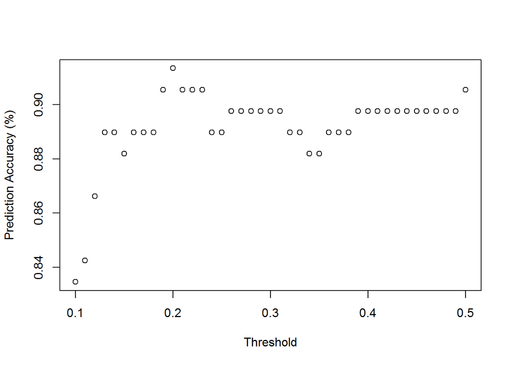

```r
plot(seq(0.1, 0.5, 0.01), logistic_pred_accuracy, xlab = "Threshold", ylab = "Prediction Accuracy (%)")
```

where, we can get the best result when threshold = 0.2.

Therefore, the final performance of logistic regression is %91.34.

Using KNN classifier

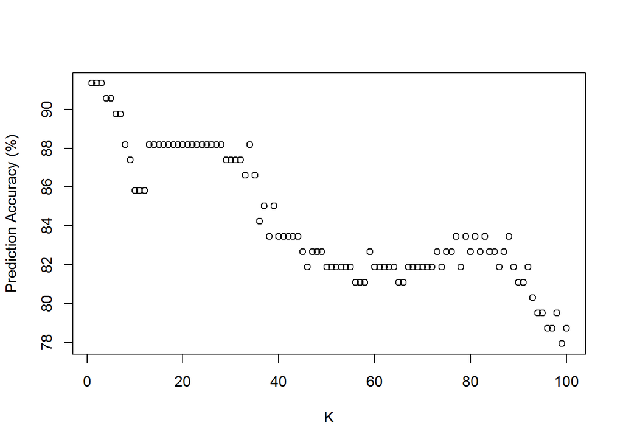

```r
library(class)
standardized.X = scale(subset(newBoston, select = c(indus, age, dis, rad, tax)))
train.X = standardized.X[train, ]
test.X = standardized.X[!train, ]
knn_accuracy = c();
for ( i in 1:100 ) {
  knn.pred = knn(train.X, test.X, train.Y, k = i)
  knn_accuracy[i] = mean(knn.pred == test.Y)*100
}
plot(1:100, knn_accuracy, xlab = "K", ylab = "Prediction Accuracy (%)")
```

```r
which.max(knn_accuracy)
```

```
## [1] 1
```

When K = 1, KNN classifier performs the best with the prediction accuracy = %91.34.

Using LDA classifier

```r
test.X = newBoston[!train, ]
library(MASS) # for lda() function
lda.fit = lda(crim01~I(indus^2)+age+I(dis^2)+poly(rad,2)+poly(tax,2)+nox:age+dis:zn, subset=train)
lda.pred = predict(lda.fit, test.X)
lda.class = lda.pred$class
table(lda.class, test.Y)
```

```
##          test.Y
## lda.class  0  1
##         0 59 13
##         1  6 49
```

Prediction accuracy for LDA = %85.04.

Using QDA classifier

```r
qda.fit = qda(crim01~I(indus^2)+age+I(dis^2)+poly(rad,2)+poly(tax,2)+nox:age+dis:zn, subset=train)
qda.pred = predict(qda.fit, test.X)
qda.class = qda.pred$class
table(qda.class, test.Y)
```

```
##          test.Y
## qda.class  0  1
##         0 62  9
##         1  3 53
```

Prediction accuracy for QDA = %90.55.

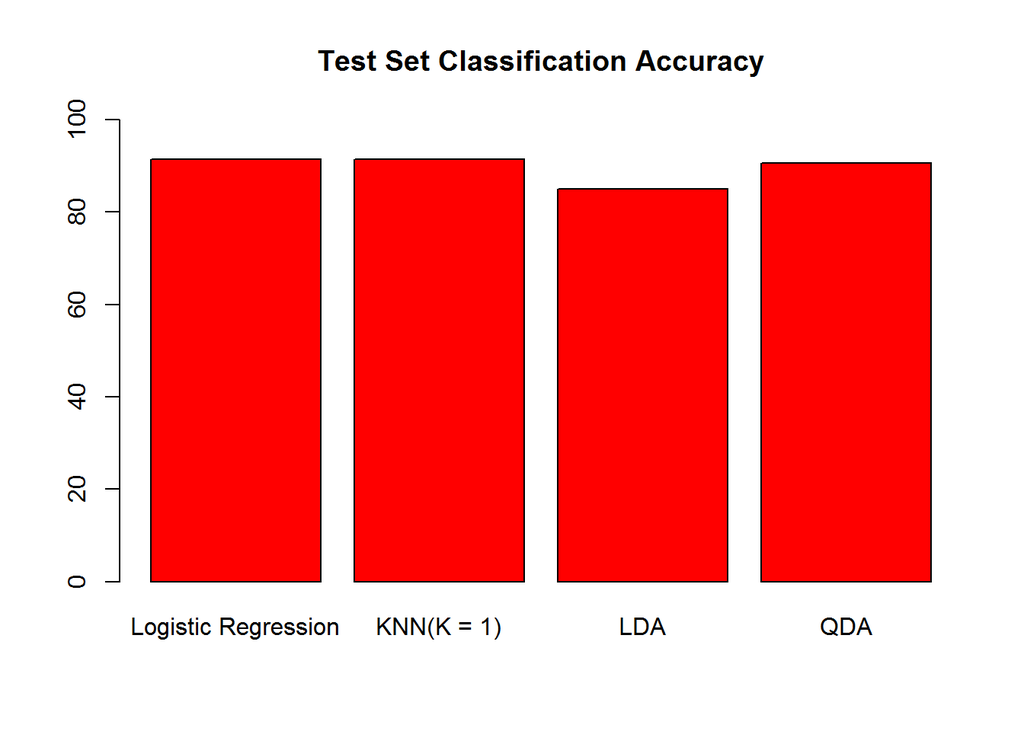

```r
barplot(c(max(logistic_pred_accuracy)*100, max(knn_accuracy), mean(lda.class == test.Y)*100, mean(qda.class == test.Y)*100), col = "red", ylim = c(0,100), names.arg = c("Logistic Regression", "KNN(K = 1)", "LDA", "QDA"), main = "Test Set Classification Accuracy")
```

**Finally, we found that there is a tie of best performance (%91.34) between logistic regression and KNN ($K = 1$), meaning that the response has a highly non-linear relationship with the predictors used, of which the data were not necessarily drawn from a normal distribution.**